# DATA 624 Spring 2019: Project-2

Ahmed Sajjad, Harpreet Shoker, Jagruti Solao, Chad Smith, Todd Weigel

April 29, 2019

```r
library(naniar)
```

```r
library(corrplot)
library(caret)
library(corrr)
library(mice)
library(randomForest)
library(dplyr)
library(e1071)
library(kernlab)
library(ranger)
library(kableExtra)
library(ModelMetrics)
```

Loading the data set

```r
project_df <-read.csv("StudentData.csv",sep=",",header=TRUE,stringsAsFactors=FALSE)
dim(project_df)
```

```
## [1] 2571   33
```

From the above result dataset has 33 variables and 2571 observations.so we have 32 predictor variables and 1 target variable. Lets look at summary of data

```r
summary(project_df)
```

```
##   Brand.Code         Carb.Volume     Fill.Ounces      PC.Volume       Carb.Pressure     Carb.Temp          PSC             PSC.Fill         PSC.CO2           Mnf.Flow       Carb.Pressure1  Fill.Pressure   Hyd.Pressure1   Hyd.Pressure2   Hyd.Pressure3   Hyd.Pressure4     Filler.Level    Filler.Spe…
##  Length:2571        Min.   :5.040   Min.   :23.63   Min.   :0.07933   Min.   :57.00   Min.   :128.6   Min.   :0.00200   Min.   :0.0000   Min.   :0.00000   Min.   :-100.20   Min.   :105.6   Min.   :34.60   Min.   :-0.80   Min.   : 0.00   Min.   :-1.20   Min.   : 52.00   Min.   : 55.8   Min.   : 99…
##  Class :character   1st Qu.:5.293   1st Qu.:23.92   1st Qu.:0.23917   1st Qu.:65.60   1st Qu.:138.4   1st Qu.:0.04800   1st Qu.:0.1000   1st Qu.:0.02000   1st Qu.:-100.00   1st Qu.:119.0   1st Qu.:46.00   1st Qu.: 0.00   1st Qu.: 0.00   1st Qu.: 0.00   1st Qu.: 86.00   1st Qu.: 98.3   1st Qu.:388…
##  Mode  :character   Median :5.347   Median :23.97   Median :0.27133   Median :68.20   Median :140.8   Median :0.07600   Median :0.1800   Median :0.04000   Median :  65.20   Median :123.2   Median :46.40   Median :11.40   Median :28.60   Median :27.60   Median : 96.00   Median :118.4   Median :398…
##                     Mean   :5.370   Mean   :23.97   Mean   :0.27712   Mean   :68.19   Mean   :141.1   Mean   :0.08457   Mean   :0.1954   Mean   :0.05641   Mean   :  24.57   Mean   :122.6   Mean   :47.92   Mean   :12.44   Mean   :20.96   Mean   :20.46   Mean   : 96.29   Mean   :109.3   Mean   :368…
##                     3rd Qu.:5.453   3rd Qu.:24.03   3rd Qu.:0.31200   3rd Qu.:70.60   3rd Qu.:143.8   3rd Qu.:0.11200   3rd Qu.:0.2600   3rd Qu.:0.08000   3rd Qu.: 140.80   3rd Qu.:125.4   3rd Qu.:50.00   3rd Qu.:20.20   3rd Qu.:34.60   3rd Qu.:33.40   3rd Qu.:102.00   3rd Qu.:120.0   3rd Qu.:399…
##                     Max.   :5.700   Max.   :24.32   Max.   :0.47800   Max.   :79.40   Max.   :154.0   Max.   :0.27000   Max.   :0.6200   Max.   :0.24000   Max.   : 229.40   Max.   :140.2   Max.   :60.40   Max.   :58.00   Max.   :59.40   Max.   :50.00   Max.   :142.00   Max.   :161.2   Max.   :403…
##                     NA's   :10      NA's   :38      NA's   :39        NA's   :27      NA's   :26      NA's   :33        NA's   :23       NA's   :39        NA's   :2         NA's   :32      NA's   :22      NA's   :11      NA's   :15      NA's   :15      NA's   :30       NA's   :20      NA's   :57 …
```

```r
#str(project_df)
```

From the summary results - The variable Brandcode is a character type .All the other variables are numeric and integers. We can see null values in all variables except Air.Pressure and Pressure.Vacuum.We can have a look through plot

```r
project_df[, c(16, 18, 21, 28)] <- sapply(project_df[, c(16, 18, 21, 28)], as.numeric) # converting int to numeric
```

Lets look at the missing values in the dataset

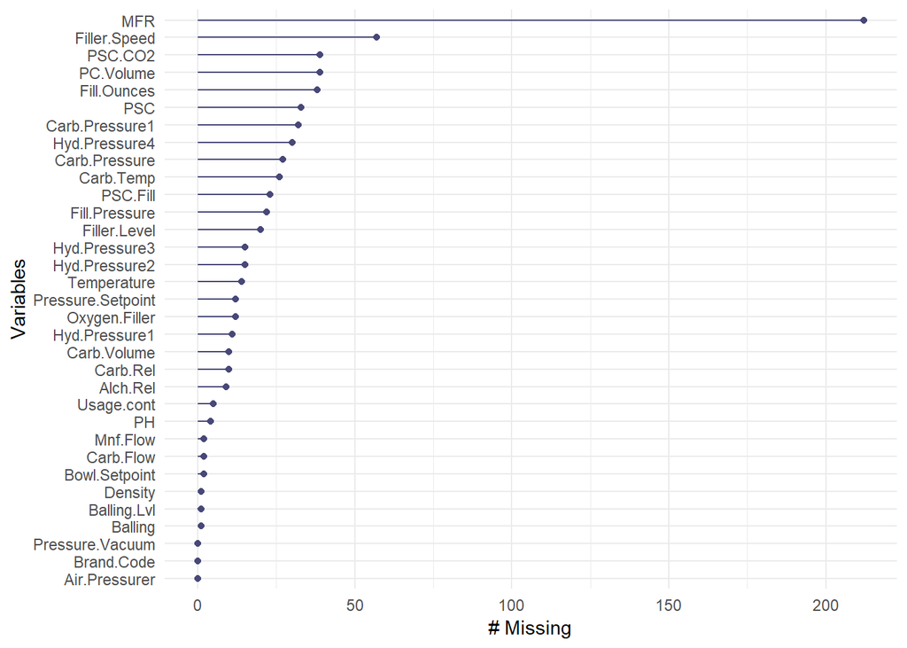

```r
gg_miss_var(project_df)
```

The above plot shows that MFR has most missing values.

To have a better look to see distribution of the variables lets plot histogram of all variables

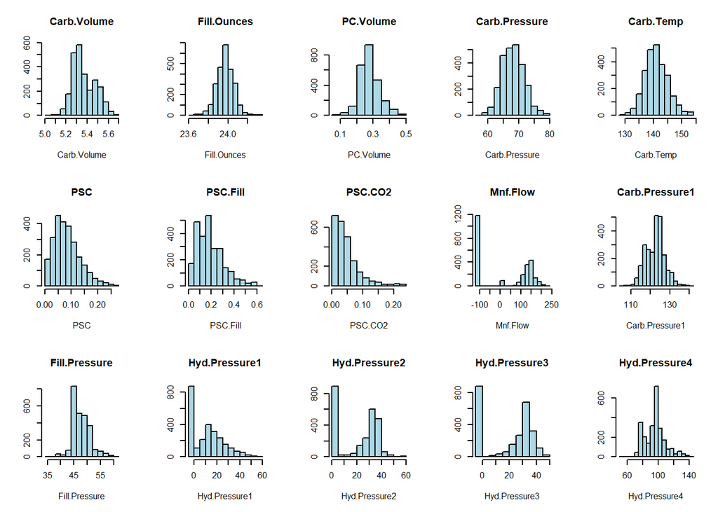

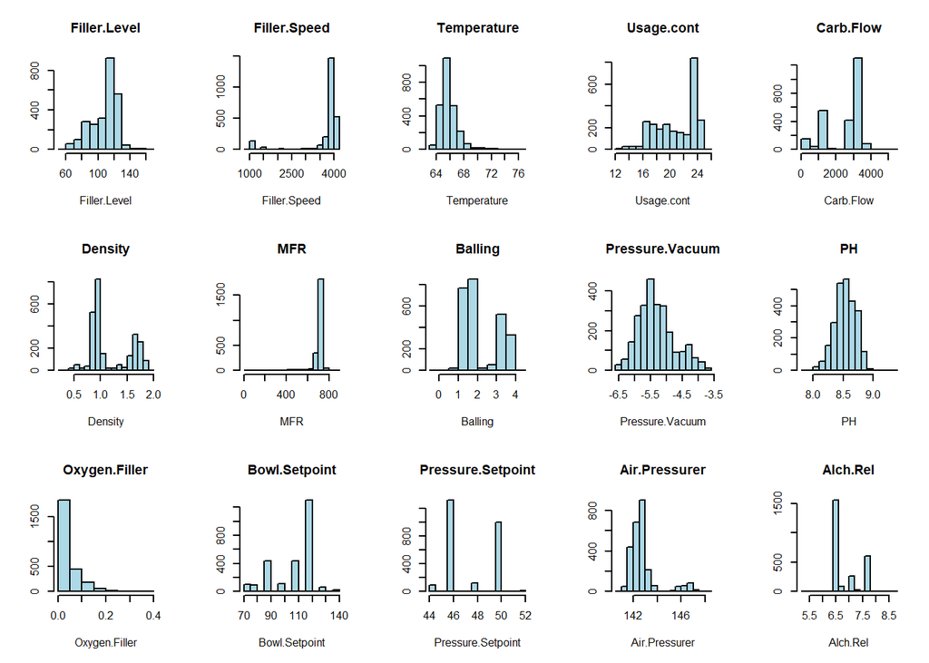

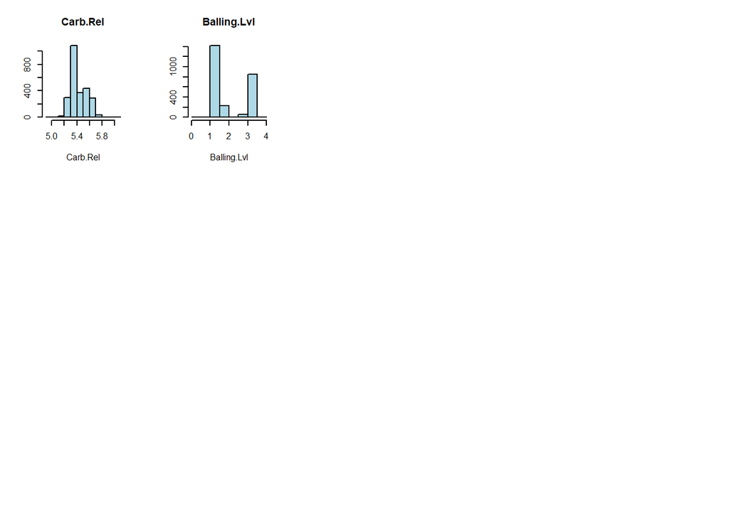

```r
par(mfrow = c(3,5), cex = .5)
project_df1 <- project_df[2:ncol(project_df)]
for(i in colnames(project_df1)){
hist(project_df1[,i], xlab = names(project_df1[i]),
  main = names(project_df1[i]), col="light blue", ylab="")
}
```

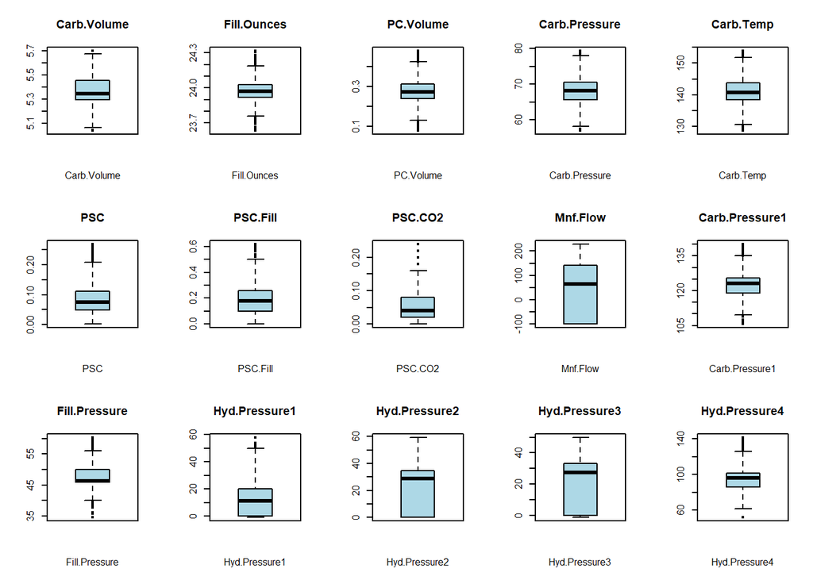

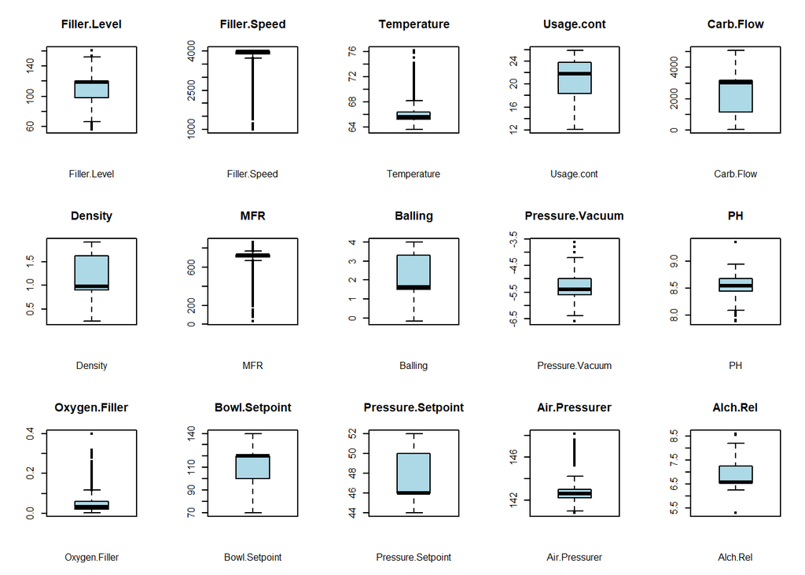

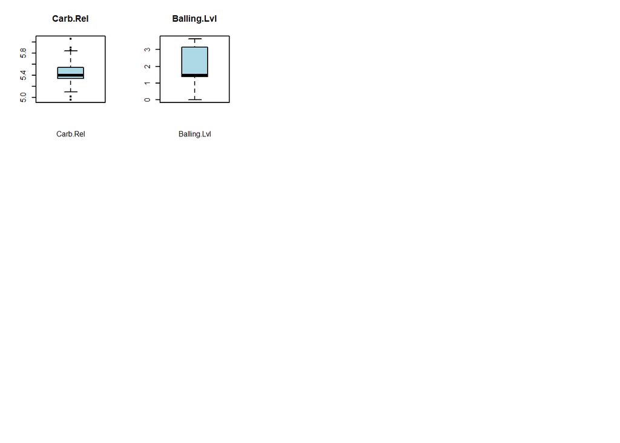

```r
par(mfrow = c(3,5), cex = .5)
for(i in colnames(project_df1)){
boxplot(project_df1[,i], xlab = names(project_df1[i]),
  main = names(project_df1[i]), col="light blue", ylab="")
}
```

CORRELATIONS BETWEEN VARIABLES :-

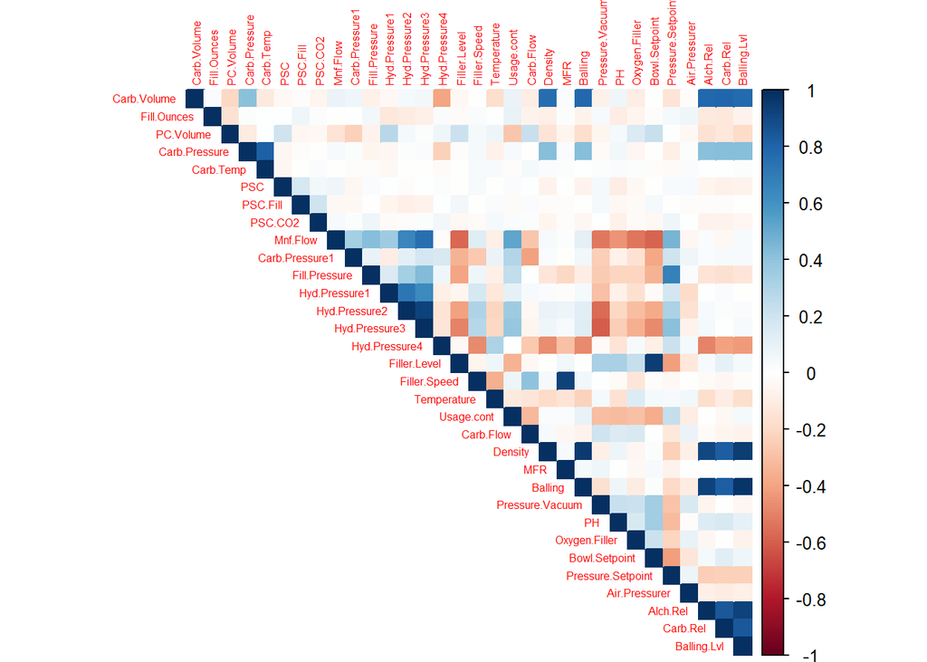

```r
plotcorr =cor(project_df1,use="pairwise.complete.obs", method = "pearson")

corrplot(plotcorr, method = "color",type = "upper", order = "original", number.cex = .7,tl.pos = "td",tl.cex = 0.5, tl.srt = 90,diag = TRUE)
```

```r
cor_var = findCorrelation(plotcorr, cutoff=0.75)
print(cor_var)
```

```
##  [1] 23  9 14 32 30 21 31 16 17  5
```

We have found out the variables that are very highly correlated with each other.

Carb.Volume with Density, Balling, Alch.Rel, Carb.Rel, and Balling.Lvl

Carb.Pressure with Carb.Temp

Filler.Level with Bowl.Setpoint

Filler.Speed with MFR

Let us now look at the correlation between the target (pH) variable and the predictors.

```r
library(ggplot2)
x <- project_df1 %>% correlate() %>% focus(PH)
```

```
##
## Correlation method: 'pearson'
## Missing treated using: 'pairwise.complete.obs'
```

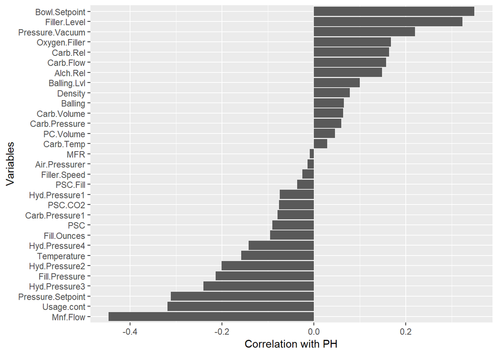

```r
x %>%
 mutate(rowname = factor(rowname, levels = rowname[order(PH)])) %>%  # Order by correlation strength
  ggplot(aes(x = rowname, y = PH)) +
    geom_bar(stat = "identity") +
    ylab("Correlation with PH") +
    xlab("Variables") + geom_col() +
    coord_flip()
```

DATA PREprocessing

Imputations - Variable Brand.code has a proportion of its data that is unspecified.

```r
library(plyr)
count(project_df$Brand.Code != "")
```

```
##       x freq
## 1 FALSE  120
## 2  TRUE 2451
```

There are around 120 values that are unspecified we will replace blank codes with “N”

```r
project_df$Brand.Code[project_df$Brand.Code==""]<- "N"
count(project_df$Brand.Code != "")
```

```
##      x freq
## 1 TRUE 2571
```

For all other missing values we will be using MICE package and a Random Forest Regression.

```r
project_df_new <- mice(data = project_df, m = 2, method = 'rf', maxit = 3)
```

Letâs compare the distributions of original and imputed data using plots.The density of the imputed data for each imputed dataset is showed in purple while the density of the observed data is showed in blue

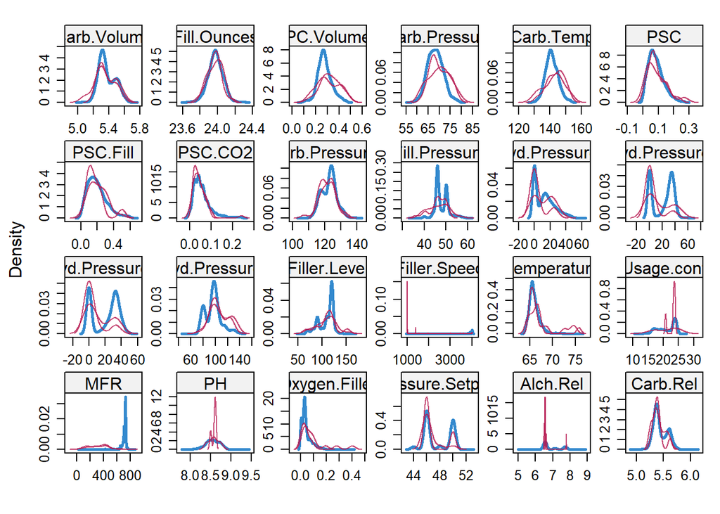

```r
densityplot(project_df_new)
```

```r
project_df_new1 <- complete(project_df_new)
```

NON Zero VARIANCE VARIABLES

```r
NZV = nearZeroVar(project_df_new1, saveMetrics = TRUE)
NZV[NZV[,"zeroVar"] > 0, ]
```

```
## [1] freqRatio     percentUnique zeroVar       nzv
## <0 rows> (or 0-length row.names)
```

```r
NZV[NZV[,"zeroVar"] + NZV[,"nzv"] > 0, ]
```

```
##               freqRatio percentUnique zeroVar  nzv
## Hyd.Pressure1   31.2963      9.529366   FALSE TRUE
```

We found that only Hyd Pressure 1 is the result. Also we already found from hist plots we observed the high number of 0 values for variables; Hyd.Pressure1, Hyd.Pressure2, and Hyd.Pressure3. We can remove these 3 variables from dataset.

```r
project_df_new1 <- project_df_new1[, -c(13:15)]
```

```r
set.seed(143)
sample = sample.int(n = nrow(project_df), size = floor(.70*nrow(project_df)), replace = F)

project_df_new1_train = project_df_new1[sample, ]
project_df_new1_test  = project_df_new1[-sample,]
```

## Model Creation

```r
myControl = trainControl(method = 'cv', number = 5, verboseIter = FALSE, savePredictions = TRUE, allowParallel = T)
```

### Linear Model

```r
set.seed(143)
linearModel_data = train(PH ~ ., data = project_df_new1_train , metric = 'RMSE', method = 'lm', preProcess = c('center', 'scale'), trControl = myControl)
lm_pred = predict(linearModel_data, newdata = project_df_new1_test)
linearModel_data
```

```
## Linear Regression
##
## 1799 samples
##   29 predictor
##
## Pre-processing: centered (32), scaled (32)
## Resampling: Cross-Validated (5 fold)
## Summary of sample sizes: 1440, 1438, 1439, 1439, 1440
## Resampling results:
##
##   RMSE       Rsquared   MAE
##   0.1345485  0.3995533  0.1043119
##
## Tuning parameter 'intercept' was held constant at a value of TRUE
```

### Support Vector Machines (SVM) Model

```r
set.seed(143)
svmRadial_data = train(PH ~ ., data = project_df_new1_train, metric = 'RMSE', method = "svmRadial", preProc =c("center", "scale"), tuneLength = 14, trControl = myControl)
svm_pred = predict(svmRadial_data, newdata = project_df_new1_test)
svmRadial_data
```

```
## Support Vector Machines with Radial Basis Function Kernel
##
## 1799 samples
##   29 predictor
##
## Pre-processing: centered (32), scaled (32)
## Resampling: Cross-Validated (5 fold)
## Summary of sample sizes: 1440, 1438, 1439, 1439, 1440
## Resampling results across tuning parameters:
##
##   C        RMSE       Rsquared   MAE
##      0.25  0.1274717  0.4702910  0.09515304
##      0.50  0.1242255  0.4928542  0.09200792
##      1.00  0.1214297  0.5126304  0.08949960
##      2.00  0.1192944  0.5275605  0.08754679
##      4.00  0.1179531  0.5390784  0.08628136
##      8.00  0.1185485  0.5374126  0.08732662
##     16.00  0.1206868  0.5262812  0.08930209
##     32.00  0.1250911  0.5035770  0.09277765
##     64.00  0.1314582  0.4741487  0.09792926
##    128.00  0.1409516  0.4316185  0.10548443
##    256.00  0.1492842  0.4011521  0.11145824
##    512.00  0.1567871  0.3754226  0.11654794
##   1024.00  0.1590294  0.3690288  0.11808576
##   2048.00  0.1590294  0.3690288  0.11808576
##
## Tuning parameter 'sigma' was held constant at a value of 0.02168288
## RMSE was used to select the optimal model using the smallest value.
## The final values used for the model were sigma = 0.02168288 and C = 4.
```

### Random Forest Model

```r
set.seed(143)
randomForest_data = train(PH ~ ., data = project_df_new1_train, metric = 'RMSE', method = 'ranger', preProcess = c('center', 'scale'), trControl = myControl)
rf_pred = predict(randomForest_data, newdata = project_df_new1_test)
randomForest_data
```

```
## Random Forest
##
## 1799 samples
##   29 predictor
##
## Pre-processing: centered (32), scaled (32)
## Resampling: Cross-Validated (5 fold)
## Summary of sample sizes: 1440, 1438, 1439, 1439, 1440
## Resampling results across tuning parameters:
##
##   mtry  splitrule   RMSE       Rsquared   MAE
##    2    variance    0.1160591  0.5938513  0.08765956
##    2    extratrees  0.1202637  0.5613225  0.09227170
##   17    variance    0.1037855  0.6536503  0.07554615
##   17    extratrees  0.1037375  0.6514745  0.07583478
##   32    variance    0.1031114  0.6524373  0.07502921
##   32    extratrees  0.1025767  0.6560001  0.07447227
##
## Tuning parameter 'min.node.size' was held constant at a value of 5
## RMSE was used to select the optimal model using the smallest value.
## The final values used for the model were mtry = 32, splitrule = extratrees and min.node.size = 5.
```

### Cubist Model

#### Reread all data to start fresh.

```r
project_df <-read.csv("StudentData.csv",sep=",",header=TRUE,stringsAsFactors=FALSE)

#cleanup
project_df$Brand.Code[project_df$Brand.Code==""]<- "N"

#compute imputed values for missing values
project_df_new <- mice(data = project_df, m = 2, method = 'rf', maxit = 3)
#and  recreate the dataframe
project_df <- complete(project_df_new)
```

### Create variables to hold data in future steps.

```r
PHTest <- NULL
dfTest <- NULL
PHTrain <- NULL
dfTrain <- NULL
PH <- project_df$PH
project_df <<- project_df[, !(names(project_df) %in% c("PH"))]
```

#### Add “dummy”" variables for the categorical column brand.

```r
#create dummy variables for the categorical brand.code
dummys <- dummyVars(~Brand.Code, data=project_df)
dfDummys <- data.frame(predict(dummys, project_df))
project_df <- bind_cols(project_df, dfDummys)
project_df <- project_df[,-1]
```

Set a seed for repeatability. Then create a function to partition data in to test and train sets. 80% goes to train, 20% to test.

```r
seed <- 42
set.seed(seed)
partition <- function(df)
{
    #divide into test and train

    partitions <- createDataPartition(seq(1, nrow(df)), p = 0.8, list = FALSE)
    dfTrain <<- df[partitions,]
    dfTest <<- df[-partitions,]

    PHTrain <<- PH[partitions]
    PHTest <<- PH[-partitions]
}
```

### Preprocess the data.

We will globably center, scale and perform boxcox transform the data. Note each of these was tested individually, and performance improved with each of these actions. PCA was tried, but even removing any of the low performing predictors had a negative impact of RMSE. If we want to improve performance we could do PCA at 95% and remove about a third of the variables.

We then call the partition function, to create the dftrain, dftest and the PHTrain and PHTest datasets.

From results of the preprocessing, we see all values were scaled and centered, and 22 had a boxcox transformation applied.

```r
##doing PCA at 95% level increases RMSE noticably (10% or so), so we won't do it.
df <- project_df
pp <- preProcess(df, method = c("BoxCox", "center", "scale"))
pp
```

```
## Created from 2571 samples and 36 variables
##
## Pre-processing:
##   - Box-Cox transformation (22)
##   - centered (36)
##   - ignored (0)
##   - scaled (36)
##
## Lambda estimates for Box-Cox transformation:
##     Min.  1st Qu.   Median     Mean  3rd Qu.     Max.
## -2.00000 -1.95000  0.10000  0.01364  1.82500  2.00000
```

```r
df <- predict(pp, df)
df <- partition(df)
```

### CV object

Set up a control object that will do cross validation, so that we improve results, by reducing chance of poor randomness in any inital paritioning.

```r
#use cross validation
#the more folds, the better the results, but the longer the processing takes.
controlObject <- trainControl(method = "repeatedcv", repeats = 5, number = 10)
```

### Cubist Grid.

The best performance from a number of different models were compared. Cubist grid was the best of those testsed. Neural Networks were a close second, but took forever (hours) to get close. SVM was also close in performance.

First set up the grid of test data.  
“Committees” are the sets of models tested and chained together. Prior models affect future models, as each data point’s weight in the current model is adjusted based on it performance in the prior model. Neighbors is a KNN algorithm that can further adjust the model based on each datapoints neighbors.

The print of the cubistgrid shows all the variations that will be tested.

Note, while developing, no test with small committees was chosen as the best model, so we are only searching with committee size of 50 or above.

```r
cubistGrid <- expand.grid(.committees = seq(50,100,10),
                          .neighbors = seq(1,9,2))
cubistGrid
```

```
##    .committees .neighbors
## 1           50          1
## 2           60          1
## 3           70          1
## 4           80          1
## 5           90          1
## 6          100          1
## 7           50          3
## 8           60          3
## 9           70          3
## 10          80          3
## 11          90          3
## 12         100          3
## 13          50          5
## 14          60          5
```

[output cut: 16 more lines]

### Execute the Cubist Model.

Note commented out because it takes forever. We will load a saved version in next cell, that has the computed model already created.

```r
# cubistModel <- train(dfTrain, PHTrain,
#                      method = "cubist",
#                      tuneGrid = cubistGrid,
#                      trControl = controlObject)
# saveRDS(cubistModel, file = "cubistModel.rds")
```

### Load the saved cubist model. And show results

We see that we get over 80% correlation on the test PH predicted value to the actual test value. And RMSE is about .10

```r
cubistModel <- readRDS("cubistModel.rds")
print(cubistModel)
```

```
## Cubist
##
## 2059 samples
##   36 predictor
##
## No pre-processing
## Resampling: Cross-Validated (10 fold, repeated 5 times)
## Summary of sample sizes: 1853, 1854, 1852, 1854, 1853, 1852, ...
## Resampling results across tuning parameters:
##
##   committees  neighbors  RMSE        Rsquared   MAE
##    50         1          0.11360173  0.6027688  0.07778046
##    50         3          0.10023103  0.6675657  0.07078980
##    50         5          0.10029336  0.6658500  0.07121976
##    50         7          0.10004140  0.6671834  0.07130446
```

[output cut: 29 more lines]

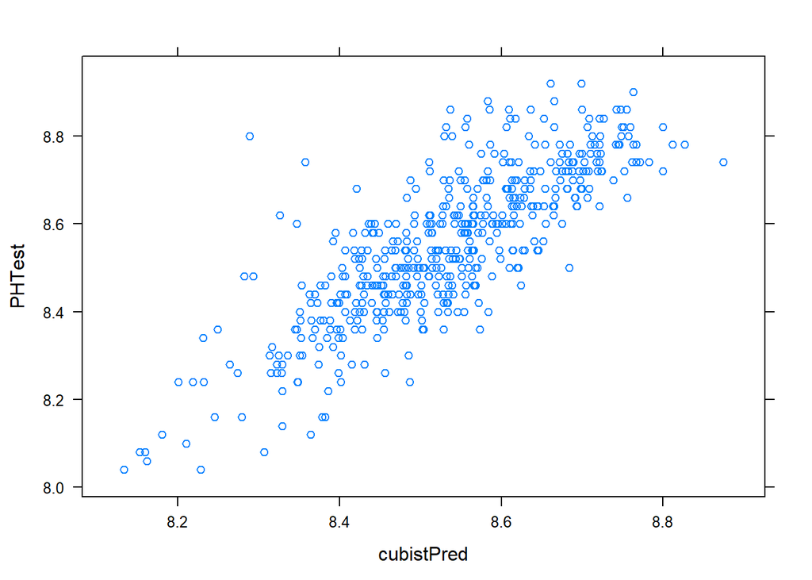

```r
cubistPred <- predict(cubistModel, dfTest)
xyplot(PHTest ~ cubistPred)
```

```r
print(cor(PHTest, cubistPred))
```

```
## [1] 0.8104545
```

```r
print(rmse(PHTest, cubistPred))
```

```
## [1] 0.1020337
```

## Compare Models

```r
#Function to display model details like RMSE etc
showModelDetails <- function(model){
  rslts <- model$results %>%
    arrange(RMSE)
  head(rslts, 10) %>% kable () %>% kable_styling(bootstrap_options = "striped", full_width = F)
}
showModelDetails(linearModel_data)
```

| intercept | RMSE | Rsquared | MAE | RMSESD | RsquaredSD | MAESD |
| --- | --- | --- | --- | --- | --- | --- |
| TRUE | 0.1345485 | 0.3995533 | 0.1043119 | 0.0027041 | 0.027324 | 0.0031755 |

```r
showModelDetails(svmRadial_data)
```

| sigma | C | RMSE | Rsquared | MAE | RMSESD | RsquaredSD | MAESD |
| --- | --- | --- | --- | --- | --- | --- | --- |
| 0.0216829 | 4.00 | 0.1179531 | 0.5390784 | 0.0862814 | 0.0035983 | 0.0314295 | 0.0017190 |
| 0.0216829 | 8.00 | 0.1185485 | 0.5374126 | 0.0873266 | 0.0039691 | 0.0323457 | 0.0017996 |
| 0.0216829 | 2.00 | 0.1192944 | 0.5275605 | 0.0875468 | 0.0032510 | 0.0349787 | 0.0021272 |
| 0.0216829 | 16.00 | 0.1206868 | 0.5262812 | 0.0893021 | 0.0039225 | 0.0347642 | 0.0013279 |
| 0.0216829 | 1.00 | 0.1214297 | 0.5126304 | 0.0894996 | 0.0029050 | 0.0352290 | 0.0020544 |
| 0.0216829 | 0.50 | 0.1242255 | 0.4928542 | 0.0920079 | 0.0026696 | 0.0309355 | 0.0020122 |
| 0.0216829 | 32.00 | 0.1250911 | 0.5035770 | 0.0927777 | 0.0041866 | 0.0368685 | 0.0023780 |
| 0.0216829 | 0.25 | 0.1274717 | 0.4702910 | 0.0951530 | 0.0031222 | 0.0301471 | 0.0021732 |
| 0.0216829 | 64.00 | 0.1314582 | 0.4741487 | 0.0979293 | 0.0050843 | 0.0453139 | 0.0034497 |
| 0.0216829 | 128.00 | 0.1409516 | 0.4316185 | 0.1054844 | 0.0057361 | 0.0557905 | 0.0035713 |

```r
showModelDetails(randomForest_data)
```

| mtry | min.node.size | splitrule | RMSE | Rsquared | MAE | RMSESD | RsquaredSD | MAESD |
| --- | --- | --- | --- | --- | --- | --- | --- | --- |
| 32 | 5 | extratrees | 0.1025767 | 0.6560001 | 0.0744723 | 0.0039229 | 0.0124156 | 0.0020111 |
| 32 | 5 | variance | 0.1031114 | 0.6524373 | 0.0750292 | 0.0035327 | 0.0103090 | 0.0036673 |
| 17 | 5 | extratrees | 0.1037375 | 0.6514745 | 0.0758348 | 0.0042394 | 0.0163701 | 0.0025948 |
| 17 | 5 | variance | 0.1037855 | 0.6536503 | 0.0755462 | 0.0034669 | 0.0093312 | 0.0031340 |
| 2 | 5 | variance | 0.1160591 | 0.5938513 | 0.0876596 | 0.0031494 | 0.0213875 | 0.0034294 |
| 2 | 5 | extratrees | 0.1202637 | 0.5613225 | 0.0922717 | 0.0043642 | 0.0253841 | 0.0031730 |

```r
showModelDetails(cubistModel)
```

| committees | neighbors | RMSE | Rsquared | MAE | RMSESD | RsquaredSD | MAESD |
| --- | --- | --- | --- | --- | --- | --- | --- |
| 100 | 9 | 0.0993298 | 0.6718650 | 0.0711839 | 0.0084149 | 0.0457490 | 0.0046282 |
| 90 | 9 | 0.0993845 | 0.6714677 | 0.0712016 | 0.0084882 | 0.0461950 | 0.0046438 |
| 80 | 9 | 0.0994455 | 0.6710807 | 0.0712038 | 0.0084662 | 0.0462172 | 0.0046041 |
| 70 | 9 | 0.0995745 | 0.6702130 | 0.0712514 | 0.0084987 | 0.0465738 | 0.0046373 |
| 60 | 9 | 0.0996443 | 0.6698102 | 0.0712848 | 0.0085334 | 0.0463564 | 0.0046568 |
| 100 | 7 | 0.0996645 | 0.6696117 | 0.0711184 | 0.0087047 | 0.0470030 | 0.0047595 |
| 90 | 7 | 0.0997098 | 0.6692817 | 0.0711315 | 0.0087660 | 0.0473857 | 0.0047681 |
| 50 | 9 | 0.0997294 | 0.6692169 | 0.0713551 | 0.0085331 | 0.0463423 | 0.0046848 |
| 80 | 7 | 0.0997716 | 0.6689003 | 0.0711310 | 0.0087496 | 0.0474427 | 0.0047426 |
| 100 | 3 | 0.0998762 | 0.6696490 | 0.0705520 | 0.0088664 | 0.0492175 | 0.0048727 |

## Load “Student Evaluation to Predict” dataset.

```r
dfToPredict <-read.csv("StudentEvaluation- TO PREDICT.csv",sep=",",header=TRUE,stringsAsFactors=FALSE)
df <- dfToPredict
```

# Clean up dataset

Just as we did with the training test file.

```r
###commented out, we will just load "cleaned up file"
#cleanup

#Remove PH Column
df <- df[, !(names(df) %in% c("PH"))]

df$Brand.Code[df$Brand.Code==""]<- "N"

#compute imputed values for missing values
df <- mice(data = df, m = 2, method = 'rf', maxit = 3)
```

```
##
##   1   1
##   1   2
##   2   1
##   2   2
##   3   1
##   3   2
```

```r
#and  recreate the dataframe
df <- complete(df)
#write.csv(df, file = "StudentEvaluation- TO PREDICT_Clean.csv", row.names = FALSE)
# #
#df <-read.csv("StudentEvaluation- TO PREDICT_Clean.csv",sep=",",header=TRUE,stringsAsFactors=FALSE)
```

### Again Create Dummy VARS

```r
#create dummy variables for the categorical brand.code

dummys <- dummyVars(~Brand.Code, data=df)
dfDummys <- data.frame(predict(dummys, df))
df <- bind_cols(df, dfDummys)
df <- df[,-1]
```

### Again Preprocess the data

(But we don’t need to partition)

```r
df <- df
pp <- preProcess(df, method = c("BoxCox", "center", "scale"))
pp
```

```
## Created from 267 samples and 36 variables
##
## Pre-processing:
##   - Box-Cox transformation (23)
##   - centered (36)
##   - ignored (0)
##   - scaled (36)
##
## Lambda estimates for Box-Cox transformation:
##    Min. 1st Qu.  Median    Mean 3rd Qu.    Max.
## -2.0000 -2.0000  0.2000 -0.2261  0.8000  2.0000
```

```r
df <- predict(pp, df)
```

Do our prediction, put them in the predicted dataset and save to a file

```r
cubistPred <- predict(cubistModel, df)
#cubistPred
dfToPredict$PH <- cubistPred
write.csv(dfToPredict, "StudentDateWithPredictedPH.csv", row.names = FALSE)
```